# Лабораторная работа №8

Имитационное Моделирование

Лисенков Е.Р.

Российский университет дружбы народов, Москва, Россия

# Информация

## Докладчик

- Лисенков Егор Романович
- студент
- Российский университет дружбы народов
- 1132232881@rudn.ru
- https://github.com/erlisenkov

# Вводная часть

## Актуальность

Дискретно-событийное моделирование позволяет изучать стохастическую динамику эпидемий на уровне отдельных индивидов, выявляя эффекты, недоступные для детерминированных моделей на дифференциальных уравнениях.

## Объект и предмет исследования

Объектом является классическая модель распространения инфекции SIR, а предметом — её дискретно-событийная реализация на языке Julia с анализом чувствительности к параметрам и оценкой производительности.

## Цели и задачи

Целью работы выступает реализация индивидуальной стохастической модели SIR, а задачами — создание ядра модели, проведение базового и параметрического экспериментов, оценка производительности и генерация отчётной документации.

## Материалы и методы

Исследование выполнено в среде Fedora Linux с использованием языка Julia, пакетов ConcurrentSim и ResumableFunctions для симуляции событий, BenchmarkTools для измерения производительности и фреймворка DrWatson для управления проектом.

## Установка пакетов для дискретно-событийного моделирования

Установлены пакеты ConcurrentSim v1.5.1, ResumableFunctions v1.0.7, Distributions, StatsPlots и BenchmarkTools для реализации логики событий и измерения производительности.

[figure not shown]

## Создание ядра модели sir_model.jl

Разработан модуль с определением структур SIRPerson и SIRModel, вспомогательных функций обновления статистики и основной сопрограммы live, описывающей жизненный цикл индивида.

[figure not shown]

## Создание скрипта базового запуска sir_des.jl

Создан скрипт с параметрами tmax=40.0, u0=[990, 10, 0], p=[0.05, 10.0, 0.25], запускающий модель и сохраняющий график динамики S, I, R.

[figure not shown]

## Выполнение скрипта базового запуска модели

Модель успешно выполнила симуляцию для 1000 индивидов, каждый из которых работал как отдельный конкурентный процесс, и сохранила график в plots/sir_des.png.

[figure not shown]

## Финальная проверка структуры проекта и артефактов

Верификация подтвердила наличие графиков sir_des.png и sir_sensitivity.png, литературных скриптов и всех производных форматов в соответствии со стандартами DrWatson.

[figure not shown]

## Выполнение скрипта анализа чувствительности

Скрипт последовательно обработал значения β=[0.03, 0.05, 0.07], вычислил пиковые значения инфицированных и сохранил сравнительный график в plots/sir_sensitivity.png.

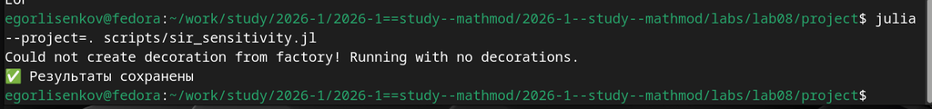

## Создание и выполнение скрипта бенчмаркинга

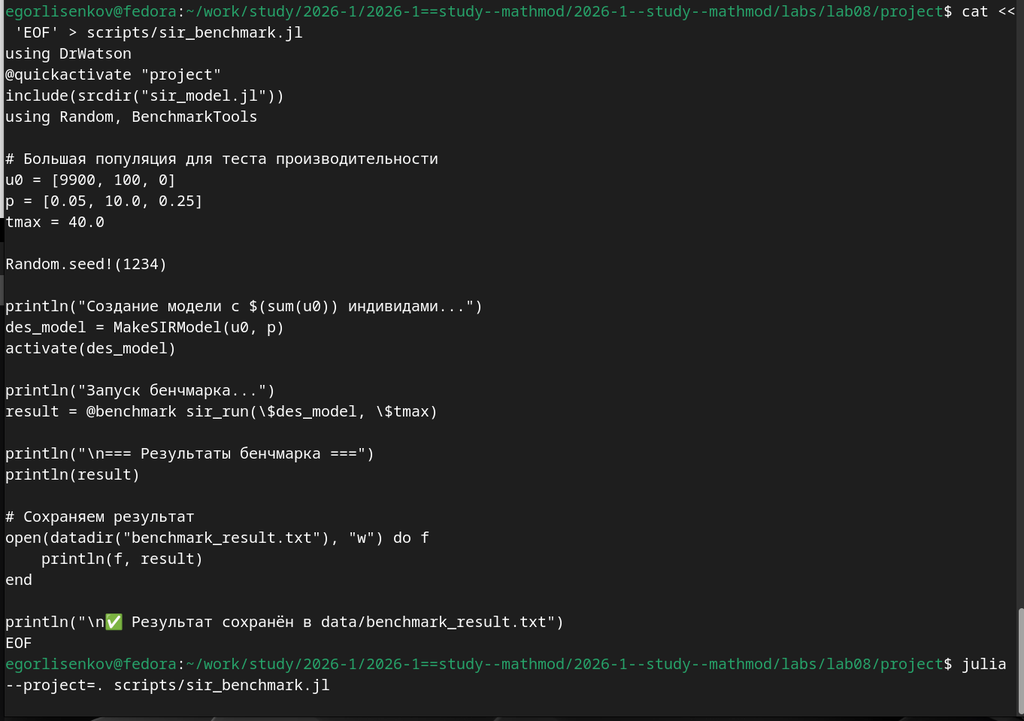

## Генерация производных форматов из литературного скрипта

Утилита tangle.jl автоматически создала чистый код, документацию Quarto и Jupyter Notebook из литературного скрипта 01_sir_basic.jl.

[figure not shown]

## Содержимое скрипта бенчмаркинга

Скрипт использует макрос @benchmark с корректной интерполяцией переменных для точного измерения времени выполнения симуляции с учётом статистического разброса.

[figure not shown]

## Содержимое литературного скрипта базового эксперимента

Файл 01_sir_basic.jl объединяет код симуляции, сбор журнала событий и визуализацию динамики численности S, I, R с помощью макроса @df.

[figure not shown]

## Выполнение параметрического исследования модели SIR

Скрипт последовательно обработал 9 комбинаций параметров (β, c, γ), вычислив пиковое число инфицированных и время достижения пика для каждой конфигурации.

[figure not shown]

## Финальная проверка структуры проекта и артефактов

Повторная верификация подтвердила полноту артефактов: графики, литературные скрипты, Quarto-документы и Jupyter Notebooks для обеих частей эксперимента.

[figure not shown]

## Содержимое литературного скрипта параметрического исследования

Скрипт 02_sir_param.jl использует dict_list для генерации комбинаций параметров и функцию savename для формирования уникальных имён выходных файлов.

[figure not shown]

## Генерация производных форматов из параметрического скрипта

Для параметрического скрипта успешно сгенерированы чистый код, Quarto-документ и интерактивный ноутбук для интеграции в итоговый отчёт.

[figure not shown]

## Результат

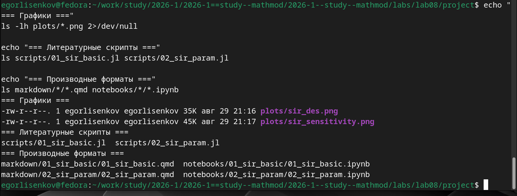

## Вывод

В результате выполнения лабораторной работы были освоены фундаментальные принципы дискретно-событийного моделирования и методология организации воспроизводимых вычислительных экспериментов на языке Julia. Практически подтверждено, что пакет ConcurrentSim в сочетании с ResumableFunctions предоставляет удобный и выразительный аппарат для описания параллельных процессов через сопрограммы и события, являясь полноценным аналогом SimPy.